# Understanding sensitive social issues on CRVS in Burkina Faso through language use: A Machine Learning Approach

Ramoudane Orou Sannou

11/08/2019

# 1. Backgound

Beyond being a mere means of communication, the language system of a community is also a carrier of collective thought. This position is all the more reinforced when it comes to thoughts on sensitive issues directly linked to local morals and culture such as birth, marriage and death. As such, understanding sensitive issues related to births, marriages and deaths registration could be achieved through careful study of language use.

As part of the UNFPA ConVERGE initiative, which aims to help selected countries improve their Civil Registration and Vital Statistics systems (CRVS), a research project to study the knowledge, social norms and cultural practices associated with the registration of births, marriages and deaths is being conducted in Burkina Faso. One question that comes to mind is the following: would it be possible to utilize machine learning - or to be more specific, text mining and Natural Language Processing (NLP) - or any other data science technique to shed light on such a topic?

As an exploratory analysis, this R markdown report will attempt to get an overview of some of the key issues discussed by publications on Birth, Marriage and Death registration in Burkina Faso. It is designed to supply our study on the ‘proximate determinants of the under-registration of vital events in Burkina Faso’ with a flow of information to better prepare for interviews/focus group and guide our analyses. It also aims to advocate for further studies on the social norms that determine vital events registration while encouraging the use of new data collection methods for this type of study.

# 2. Text Mining

Text mining is a text analytics process that aims to discover relevant information that is possibly unknown or buried beneath words. Natural Language Processing (NLP) is one text mining methodology. It tries to decipher the ambiguities in written language by tokenization, clustering, extracting entity and word relationships, and using algorithms to identify themes and quantify subjective information [(Liske, 2018)](https://www.datacamp.com/community/tutorials/R-nlp-machine-learning). For this study I will try to decipher from my analyses, the popular thought about civil registration in Burkina Faso, focusing on aspects related to socio-cultural norms and gender.

## 2.1. Loading useful packages

```r
library(readxl)      # To import .xlsx file into R
library(tidyverse)   # For data manipulation & vizualization
library(tidytext)    # For text data manipulation
library(stopwords)   # To deal with stop/useless words
library(tm)          # For text mining
library(SnowballC)   # Lemmatization / stemmatization
library(topicmodels) # Create topic models
library(ggpubr)      # Create beautiful ggplot2-based graphs
library(knitr)       # Produce nice tables outputs
```

## 2.2. Loading the dataset

Limitation: I could have used web-scraping to collect the texts but as some of the texts were collected from books and other types of publications, I used a spreadsheet as a database. Another approach would have been to copy the texts to word and then import the .docx or .txt files to R and merge them with an excel file containing the meta information for each text.

```r
unstructured_BMD <-
read_excel(
"/Users/ramoudaneorousannou/unfpa_bf/Unstructured_Birth_Marriage_Death_Reg_Bf.xlsx") %>%
select("Num", "Year", "Publication_Type", "Source_Type", "Vital_Event", "Text")
# Source variable is just a bunch of links so I drop it for now
```

## 2.3. Total publications collected

```r
Total_Publications_Collected_On_Vital_Events <-
unstructured_BMD %>%
group_by(Vital_Event) %>%
count()

Total_Publications_Collected_On_Vital_Events %>%
kable(format = "pipe", row.names = FALSE)
```

| Vital_Event | n |
| --- | --- |
| Birth | 19 |
| Death | 1 |
| Marriage | 13 |

In total, between 2004 and 2019 I obtained 33 online available publications on the topic. There are certainly publications discussing birth, marriage and death registration in Burkina Faso that have been missed, especially those that are not on the web. I have got 19 publications on birth registration, 13 on mariage and only 1 on Death registration. This already suggests that death registration is currently not a topical issue in Burkina Faso.

## 2.4. Publications types

```r
Publication_Types_by_Year <-
 unstructured_BMD %>%
 group_by(Publication_Type) %>%
 count()

Publication_Types_by_Year %>%
kable(format = "pipe", row.names = FALSE)
```

| Publication_Type | n |
| --- | --- |
| Academic | 4 |
| Online Newspapper | 27 |
| Online Radio | 1 |
| Presse release | 1 |

One striking result is that the social norms that influence vital events registration in Burkina Faso are hardly addressed in the academic literature. Only 4 academic documents that I could find discussed the issue. However, some academic documents may be available in hard copy, offline. Most of the publications used in this R markdown come from online newspapers, in particular [“Le Faso.net”](https://lefaso.net/) which has extensively discussed the subject and from [“Jeune Afrique”](https://www.jeuneafrique.com/). Other online newspapers such as [“Fasozine.com”](http://www.fasozine.com/), [“lepays.bf”](http://lepays.bf/), [“touteinfo.com”](http://www.touteinfo.com/), [“fasoamazone.net”](https://www.fasoamazone.net/) have been scrutinized using french keywords such as **naissance**, **mariage**, **décès**.

For a coherent text mining process and given that Burkina Faso is a French-speaking country, I limited my search to texts written in French.

## 2.5. Publications on vital events over the years

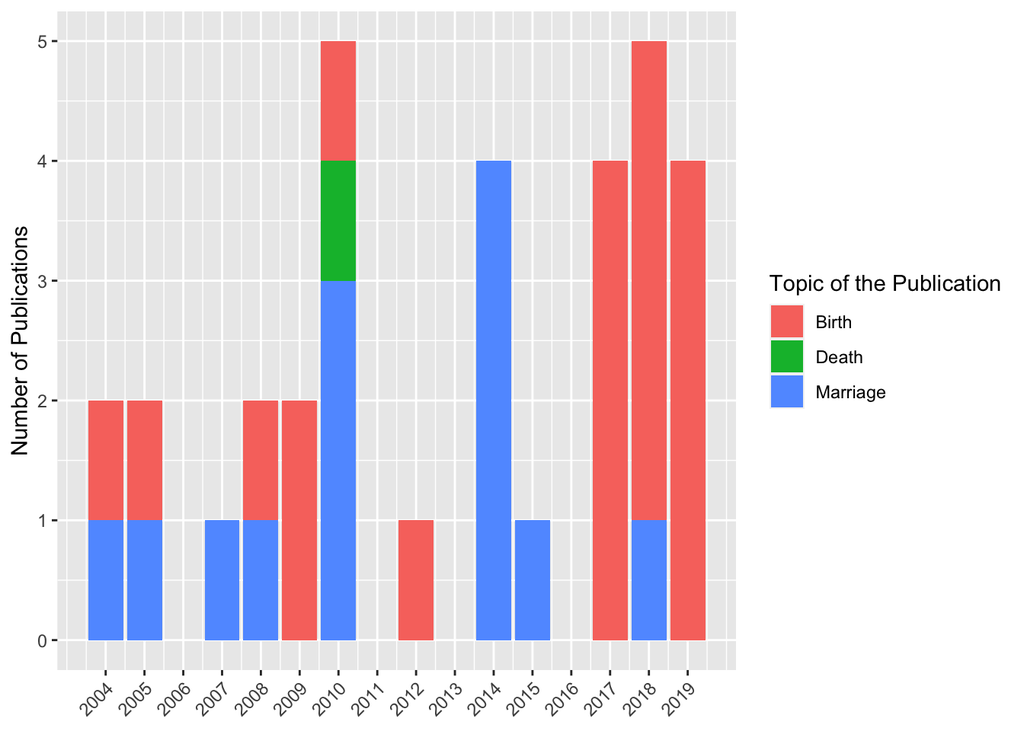

```r
Publications_by_Year <-
 unstructured_BMD %>%
 group_by(Year, Vital_Event) %>%
 count() %>%
 ungroup()

Plot_Publications_Count <-
 Publications_by_Year %>%
 ggplot(aes(Year, n, fill = Vital_Event)) +
 geom_col() +
 labs(#title = paste("Online Publications on Birth, Marriage & Death
 #Registration in Burkina Faso By Year"),
     x = NULL,
     y = "Number of Publications",
  fill = "Topic of the Publication") +
  theme(plot.title = element_text(hjust = 0.5),
        axis.text.x = element_text(angle = 45, hjust =  1)) +
  scale_x_continuous(breaks= seq(2004, 2019))

Plot_Publications_Count
```

The publications I found were from 2004 to 2019 and the majority of them focus on birth registration, with 2010 and 2018 having the highest number of publications. Note that most of the publications in the early years focus on birth registration, indicating that the issue has been topical for more than 15 years (because the advent of internet in Burkina Faso is likely to be recent). The same applies to marriages. Conversely, Death registration is rarely discussed and the only publication found in the news was from 2010.

## 2.6. Data Contidionning : let’s try to add structure to the data

I need to impose structure to the data in order to analyse it. Using the *tidytext* package, I will apply a process called **“tokenization”** which transforms a text into a bag of single words.

```r
# Tokenizing the unstructured_BMD dataframe (1)

token_BMD <- unstructured_BMD %>%
rename(id = Num) %>%
unnest_tokens(word, Text)
```

```r
# Counting words before removal of stop words to find out the 30 most used words

token_BMD %>%
count(word) %>%
arrange(desc(n)) %>%
head(10) %>%
kable(format = "pipe", row.names = FALSE)
```

| word | n |
| --- | --- |
| de | 1470 |
| la | 732 |
| le | 596 |
| les | 596 |
| des | 587 |
| et | 581 |
| à | 359 |
| en | 339 |
| du | 282 |
| pour | 249 |

```r
# Removing stop words, first method

tidy_BMD <- token_BMD %>%
filter(!word %in% stopwords("fr"))




# Counting remaining words to find out those that were used most frequently (1)
tidy_BMD %>%
count(word) %>%
arrange(desc(n)) %>%
head(n = 10) %>%
kable(format = "pipe", row.names = FALSE)
```

| word | n |
| --- | --- |
| a | 213 |
| à | 204 |
| mariage | 183 |
| plus | 154 |
| civil | 117 |
| naissance | 104 |
| c’est | 83 |
| comme | 81 |
| femmes | 81 |
| naissances | 66 |

This shows us the most commonly used words in the texts. Words like **“de”, “la”, “le”** have the highest frequency but do not give us any significant insight from the texts (they are called “stop words”). I will therefore delete them using a collection of stop words available in the *“stopwords”* package.

## 2.7. Word frequency

### 2.7.1. Plot words based on their frequencies (1st attempt)

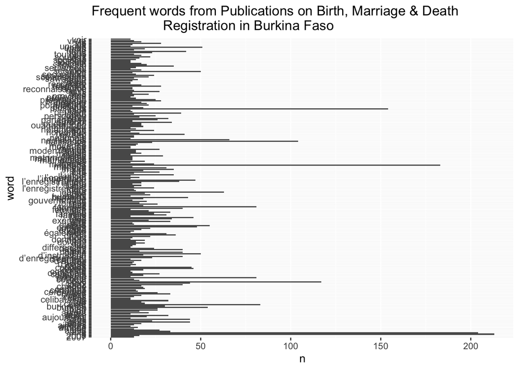

```r
# Creating new object for remaining words

BMD_word_counts <- tidy_BMD %>%
count(word) %>%
filter(n>10) %>%
arrange(desc(n))

# Plotting the remaining words (1)

ggplot(BMD_word_counts, aes(word, n)) +
geom_col() +
coord_flip() +
ggtitle("Frequent words from Publications on Birth, Marriage & Death
                   Registration in Burkina Faso")
```

There are a number of things wrong with this bar plot. I will use another approach to remove stop words.

```r
# Removing stop words, second method
glimpse(stopwords('fr'))
```

```
##  chr [1:164] "au" "aux" "avec" "ce" "ces" "dans" "de" "des" "du" "elle" ...
```

```r
# Creating a dataframe of french stop words with tm
fr_stopwords <- tibble(word = stopwords('fr'))

# Tokenizing the unstructured_BMD dataframe (2)
token_BMD2 <- unstructured_BMD %>%
rename(id = Num) %>%
unnest_tokens(word, Text) %>%
anti_join(fr_stopwords)
```

```r
# Counting remaining words to find out the 30 most used words (2)
token_BMD2 %>%
count(word) %>%
arrange(desc(n)) %>%
head(10) %>%
kable(format = "pipe", row.names = FALSE)
```

| word | n |
| --- | --- |
| a | 213 |
| à | 204 |
| mariage | 183 |
| plus | 154 |
| civil | 117 |
| naissance | 104 |
| c’est | 83 |
| comme | 81 |
| femmes | 81 |
| naissances | 66 |

Got the same result…

It appears that there are still some unecessary words that were not removed by the standard collection of stopwords. I will remove them manualy.

```r
# Creating a new dataframe of words I would like to remove manually

custom_french_stopwords <-
  tribble( ~word,"a", "à", "burkina", "aussi", "ainsi", "pays", "faso", "civil",
           "état", "acte", "actes", "plus", "naissance", "naissances", "être",
           "enfant", "tout", "mariage", "enfant", "enfants", "selon", "union",
           "fait", "comme", "burkinabè", "ouédraogo", "72", "1988", "000",
           "ouagadougou", "qu’il", "pogbi", "compaoré", "deux", "peut", "un",
           "ans", "où", "cas", "si", "est", "est", "chez", "une", "même"
           ,"2007","sawadogo" )

#Joining the created stop words to the standard stop words

fr_stopwords2 <- fr_stopwords %>%
bind_rows(custom_french_stopwords)
glimpse(fr_stopwords2)
```

```
## Rows: 211
## Columns: 1
## $ word <chr> "au", "aux", "avec", "ce", "ces", "dans", "de", "des", "du", "el…
```

```r
# Tokenizing the unstructured_BMD dataframe (3)
token_BMD3 <- unstructured_BMD %>%
unnest_tokens(word, Text) %>%
anti_join(fr_stopwords2)

# stemmatizing to get the stem of each word
# mutate(word1 = wordStem(word, language = "fr"))
# stemmatization seems to have limited effects on french words

# Get rid of apostrophes and perform some manual stemmatization by creating a
# function that handles most scenarios using gsub(),
# and then apply that function across all words

fix_apostrophe <- function(w) {
  # I am using "w" to mean "word"
  w <- gsub("l'enregistrement", "enregistrement", w)
  w <- gsub("l’enregistrement", "enregistrement", w)
  w <- gsub("d’enregistrement", "enregistrement", w)
  w <- gsub("l’enregistrement", "enregistrement", w)
  w <- gsub("l'importance", "importance", w)
  w <- gsub("l’importance", "importance", w)
  w <- gsub("l'hôpital", "hôpital", w)
  w <- gsub("l’hôpital", "hôpital", w)
  w <- gsub("l'unicef", "unicef", w)
  w <- gsub("d'actes", "actes", w)
  W <- gsub("d’actes", "actes", w)
  w <- gsub("l’acte", "acte", w)
  w <- gsub("l’union", "union", w)
  w <- gsub("c’est", "est", w)
  w <- gsub("l’état", "état", w)
  w <- gsub("l'état", "état", w)
  w <- gsub("d’état", "état", w)
  w <- gsub("d'état", "état", w)
  w <- gsub("d’un", "un", w)
  w <- gsub("l’eglise", "eglise", w)
  w <- gsub("l’opération", "opération", w)
  w <- gsub("l’enfant", "enfant", w)
  w <- gsub("l’unicef", "unicef", w)
  w <- gsub("d’autres", "autres", w)
  w <- gsub("hommes", "homme", w)
  w <- gsub("femmes", "femme", w)
  w <- gsub("couples", "couple", w)
  w <- gsub("filles", "femme", w)
  w <- gsub("d’instruction", "instruction", w)
  w <- gsub("l’âge" , "âge", w)
  w <- gsub("droits", "droit", w)
  w <- gsub("maternités", "maternié", w)
  w <- gsub("centres", "centre", w)
  w <- gsub("maire", "mairie", w)
  w <- gsub("familles", "famille", w)
  return(w)
}
# fix apostrophe issue
token_BMD3$word <- sapply(token_BMD3$word, fix_apostrophe )

# Removing stop words that appeard after I fixed the apostrophe issue
token_BMD3 <- token_BMD3 %>%
anti_join(fr_stopwords2)
```

```r
# Counting remaining words to find out the 30 most used words, second attempt
token_BMD3 %>%
count(word) %>%
arrange(desc(n)) %>%
head(10) %>%
kable(format = "pipe", row.names = FALSE)
```

| word | n |
| --- | --- |
| femme | 147 |
| couple | 91 |
| enregistrement | 89 |
| mairie | 66 |
| jeunes | 63 |
| homme | 61 |
| centre | 59 |
| droit | 58 |
| entre | 55 |
| famille | 55 |

```r
token_BMD3 %>%
filter(Vital_Event == "Marriage") %>%
count(word) %>%
filter(word == "lévirat")
```

```
## # A tibble: 1 x 2
##   word        n
##   <chr>   <int>
## 1 lévirat     4
```

```r
# arrange(desc(n)) %>%
# head(200) %>%
# print(n = 200)
```

This list looks much better. Surprizingly, I now have **“femme” (woman)** as the most used word - even more than **“enregistrement” (registration) and “état” (“état civil” is the french translation of “civil registration”)**. This already draws our attention to the central role that women play when it comes to the registration of vital events in Burkina Faso. In addition, a word that appears only four times but refers to a cultural practice related to marriage is **"lévirat**“.”lévirat" refers to the obligation of the real or classificatory brother of a deceased man to marry his widow or widows. It is a widespread practice in West Africa, although it has various conditions for its implementation: it can be imposed, prescribed, recommended or left to the widow’s choice [(Attané, 2014)](https://www.jstor.org/stable/j.ctt1f117sb).

### 2.7.2. Plot words based on their frequencies (2nd attempt)

```r
# Creating new object for remaining words

BMD_word_counts <- token_BMD3 %>%
count(word, Vital_Event) %>%
arrange(desc(n)) %>%
group_by(Vital_Event) %>%
top_n(25, n) %>%
ungroup()

BMD_word_counts %>%
head(10) %>%
kable(format = "pipe", row.names = FALSE)
```

| word | Vital_Event | n |
| --- | --- | --- |
| femme | Marriage | 131 |
| couple | Marriage | 91 |
| enregistrement | Birth | 89 |
| jeunes | Marriage | 62 |
| homme | Marriage | 58 |
| centre | Birth | 51 |
| mairie | Marriage | 51 |
| famille | Marriage | 49 |
| choix | Marriage | 44 |
| droit | Birth | 41 |

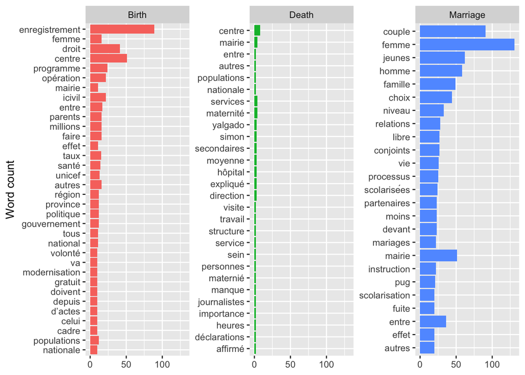

```r
# Plotting the remaining words

ggplot(BMD_word_counts, aes(reorder(word, n), n, fill = Vital_Event )) +
geom_col(show.legend = FALSE) +
facet_wrap(~ Vital_Event, scales = "free_y") + # The y axis can be different for each plot
coord_flip() +
theme(plot.title = element_text(hjust = 0.5)) +
labs(#title = paste("Frequent words from Publications on Birth, Marriage & Death
                   #Registration in Burkina Faso"),
     x = "Word count",
     y = NULL)
```

This plot is not sorted. Although I have rearranged the words according to their frequency, ggplot doesn’t seem to handle them perfectly. I will try to find out what is wrong and how to improve the visualization.

### 2.7.3. Plot words based on their frequencies (3rd attempt)

Since the facetting variable is a factor, reordering with ggplot doesn’t produce the best result. I will now produce one plot for each vital event and put them side by side using the ggpubr package.

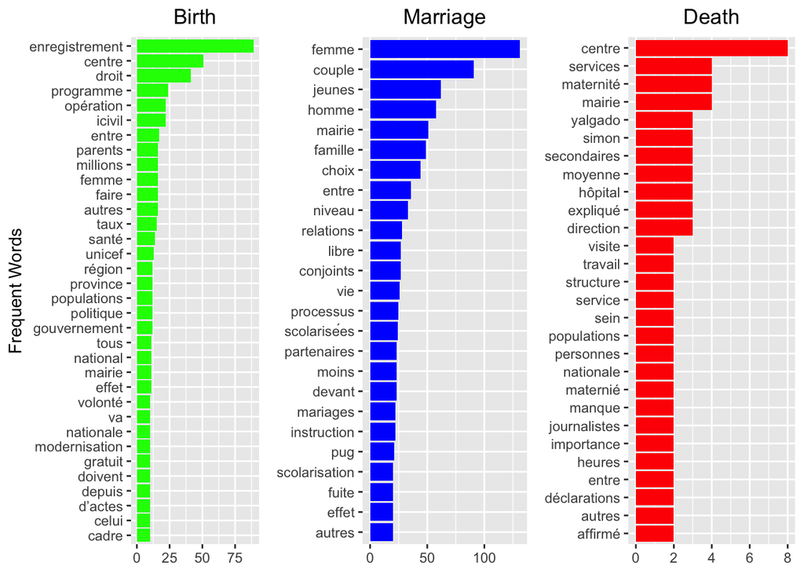

```r
#BMD_word_counts[, word] <- as.factor(BMD_word_counts[, word])
#BMD_word_counts[, Vital_Event] <- as.factor(BMD_word_counts[, Vital_Event])
# Plotting the remaining words
#BMD_word_counts_sorted <- BMD_word_counts %>%
  #arrange(desc(n)) %>%
  #pull(word)
#head(BMD_word_counts_sorted)



#BMD_word_counts_sorted <- BMD_word_counts %>%
#arrange(desc(n)) %>%
#pull(word)

#head(BMD_word_counts_sorted)
#str(BMD_word_counts_sorted)
#BMD_word_counts[ ,'word'] <-
#factor(BMD_word_counts[ ,'word'],
#levels = as.character(BMD_word_counts_sorted['word']))


BMD_word_counts <- BMD_word_counts %>%
mutate(word = fct_reorder(word, n))

BMD_word_counts <- BMD_word_counts %>%
arrange(desc(n))
#head(BMD_word_counts)
#levels(BMD_word_counts$word)
#BMD_word_counts$word[duplicated(BMD_word_counts$word)]
#BMD_word_counts$word <-
#factor(BMD_word_counts, levels = as.character(BMD_word_counts$word))


#I will now produce one plot for each vital event and put them side by side.

BMD_word_counts_birth <- BMD_word_counts %>%
  filter(Vital_Event == "Birth")

BMD_word_counts_birth$word <-
  factor(BMD_word_counts_birth$word,
         levels = as.character(BMD_word_counts_birth$word))

BMD_word_counts_marriage <- BMD_word_counts %>%
  filter(Vital_Event == "Marriage")

BMD_word_counts_marriage$word <-
  factor(BMD_word_counts_marriage$word, levels = as.character
         (BMD_word_counts_marriage$word))

BMD_word_counts_death <- BMD_word_counts %>%
  filter(Vital_Event == "Death")

BMD_word_counts_death$word <-
  factor(BMD_word_counts_death$word, levels = as.character
         (BMD_word_counts_death$word))


gg_birth <-
  ggplot(BMD_word_counts_birth, aes(x = reorder(word, n), y = n)) +
  geom_col(show.legend = FALSE, fill = 'green') +
  theme(plot.title = element_text(hjust = 0.5)) +
  coord_flip() +
  labs(title = 'Birth', x = 'Frequent Words', y = NULL)

gg_marriage <-
  ggplot(BMD_word_counts_marriage, aes(x = reorder(word, n), y = n)) +
  geom_col(show.legend = FALSE, fill = 'blue') +
  theme(plot.title = element_text(hjust = 0.5)) +
  coord_flip() +
  labs(title = "Marriage", x = NULL,  y = NULL)

gg_death <-
  ggplot(BMD_word_counts_death, aes(x = reorder(word, n), y = n)) +
  geom_col(show.legend = FALSE, fill = 'red') +
  theme(plot.title = element_text(hjust = 0.5)) +
  coord_flip() +
  labs(title = "Death", x = NULL, y = NULL)

ggarrange(gg_birth, gg_marriage, gg_death, nrow = 1,
          common.legend = TRUE, legend = "right")
```

### 2.7.4. Word count for Birth registration

Based on this plot, I could notice that the word **“enregistrement” (registration)** came out strongly from publications on birth. This is normal as the publications were on birth registration. However, this also tells us that birth Registration in Burkina Faso is often viewed as a simple “registration” act and not necessarily as a “social act”. There are also words like **“droit” (right), “gouvernement” (government)**, that reveal governmental strong implication in getting all births counted in Burkina Faso. The presence of **“icivil”**, which is a newly introduced birth registration technology via mobile phone, indicates a strong inclination to modernize the system, notwithstanding limiting factors such as the accessibility and availability of the technology in **“province”** or **“region”** which are also words that have appeared.

### 2.7.5. Word count for Death registration

It is difficult to make sense of the graph on death registration because there was only one publication on this subject. Nevertheless, this suggests that little is being done to register deaths and that it would be important for our study to shed light on the reasons for this situation.

### 2.7.6. Word count for Marriage registration

For publications on marriages, the word ‘’femme’’ appears more frequently and reflects the central role that women play on this issue. I also notice the frequent use of the word **‘’scolarisées’’ (educated)** and “instruction”. Here, the presence of the *‘’es’’* at the end of the word indicates that it is used as a verb for a female pronoun, therefore it refers to women’s education. I can infer that women’s education is linked to their marriage and ultimately to the registration of marriages.

A word that appeared with a relatively high frequency and that seemed a priori meaningless to us is **“pug”**. After a review of some texts on marriage, I realized that **“pug”** is the stem of several words in the local language such as **“pug-siure” (engagement ceremony)**, **“pug-pusum” (marriage proposal to a woman’s family)**. **“Pug”** means **“woman”** in the local dialect and therefore reinforces the argument that women are at the center of the debates on marriage registration.

# 3. Topic Modeling

Topic modeling allows us to move beyond simple word counts and uncover the underlying topics in our collection of documents (in this case, our transformed publications). I will use a standard topic model known as Lattent Dirichlet Allocation (LDA). The LDA model is a type of unsupervised learning approach that seaches for patterns of words consitently occuring together accross a collection of documents. Before runing our topic model, I need to transform the collection of words (token_BMD3) into a collection of documents called Document Term Matrix (DTM). A DTM is a matrix that has a single row for each document (publication) and a column for every unique word (or term). The values in the DTM are the counts of each term for a given document in a row.

## 3.1. Topic modeling for birth registration

```r
dtm_publications_birth <- token_BMD3 %>%
rename(id = Num) %>% # to rename the num column
filter(Vital_Event == "Birth") %>%
count(word, id) %>%
cast_dtm(id, word, n)
dtm_publications_birth
```

```
## <<DocumentTermMatrix (documents: 19, terms: 2012)>>
## Non-/sparse entries: 3526/34702
## Sparsity           : 91%
## Maximal term length: 19
## Weighting          : term frequency (tf)
```

```r
matrix_dtm_publications_birth <-
  as.matrix(dtm_publications_birth)
matrix_dtm_publications_birth[1:5, 100:105]
```

```
##     Terms
## Docs acteurs action actions activité activités actuel
##   8        1      0       0        0         0      0
##   24       1      0       1        0         0      1
##   27       0      0       0        0         0      0
##   7        0      0       0        0         0      0
##   26       0      0       0        0         0      0
```

```r
lda_publications_birth <- LDA(dtm_publications_birth,
                        k = 2,
                        method = "Gibbs",
                        control = list(seed = 42))
glimpse(lda_publications_birth)
```

```
## Formal class 'LDA_Gibbs' [package "topicmodels"] with 16 slots
##   ..@ seedwords      : NULL
##   ..@ z              : int [1:4434] 1 1 2 1 1 1 1 1 2 2 ...
##   ..@ alpha          : num 25
##   ..@ call           : language LDA(x = dtm_publications_birth, k = 2, method = "Gibbs", control = list(seed = 42))
##   ..@ Dim            : int [1:2] 19 2012
##   ..@ control        :Formal class 'LDA_Gibbscontrol' [package "topicmodels"] with 14 slots
##   ..@ k              : int 2
##   ..@ terms          : chr [1:2012] "0" "09" "1" "1,2" ...
##   ..@ documents      : chr [1:19] "8" "24" "27" "7" ...
##   ..@ beta           : num [1:2, 1:2012] -6.98 -10.16 -7.63 -10.16 -6.59 ...
##   ..@ gamma          : num [1:19, 1:2] 0.507 0.336 0.83 0.399 0.784 ...
##   ..@ wordassignments:List of 5
##   .. ..$ i   : int [1:3526] 1 1 1 1 1 1 1 1 1 1 ...
##   .. ..$ j   : int [1:3526] 1 17 29 30 31 46 64 65 76 100 ...
##   .. ..$ v   : num [1:3526] 1 1 2 1 1 1 2 1 2 2 ...
##   .. ..$ nrow: int 19
##   .. ..$ ncol: int 2012
##   .. ..- attr(*, "class")= chr "simple_triplet_matrix"
##   ..@ loglikelihood  : num -33565
##   ..@ iter           : int 2000
##   ..@ logLiks        : num(0)
##   ..@ n              : int 4434
```

```r
lda_publications_birth_topics <-
  lda_publications_birth %>%
  tidy(matrix = "beta" )

lda_publications_birth_topics %>%
arrange(desc(beta))
```

```
## # A tibble: 4,024 x 3
##    topic term              beta
##    <int> <chr>            <dbl>
##  1     2 enregistrement 0.0346
##  2     2 droit          0.0160
##  3     1 centre         0.0133
##  4     1 icivil         0.00978
##  5     1 opération      0.00978
##  6     2 programme      0.00935
##  7     2 centre         0.00819
##  8     1 millions       0.00712
##  9     2 autres         0.00625
## 10     2 femme          0.00625
## # … with 4,014 more rows
```

I defined k = 2 because I want the model to group the words into two topics. The result shows us “beta” which is the probability of words appearing in a given topic.

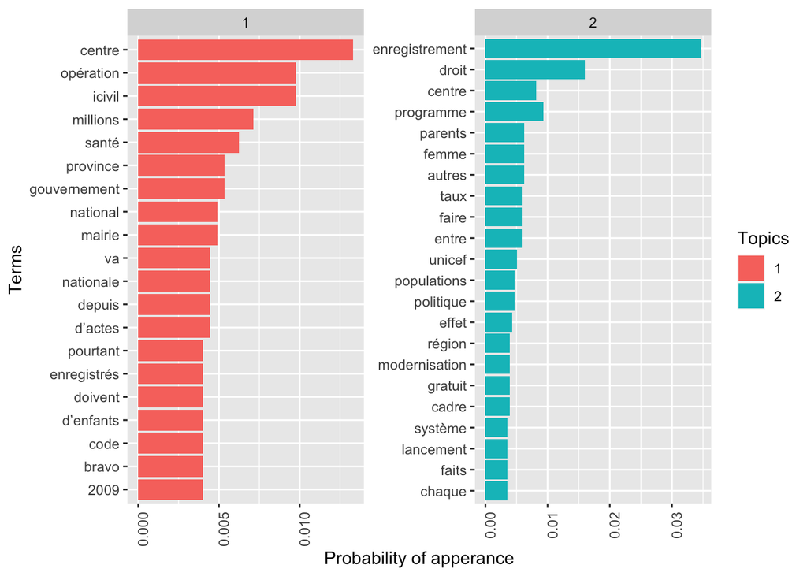

```r
# Creating an object for words' probabilities of appearance

word_prob_birth <-
  lda_publications_birth_topics %>%
  group_by(topic) %>%
  top_n(20, beta) %>%
  ungroup() %>%
  mutate(term2 = fct_reorder(term, beta))

# Ploting words' propabilities

ggplot(word_prob_birth, aes(term2, beta, fill = as.factor(topic))) +
  geom_col() +
  facet_wrap(~ topic, scales = "free") +
  coord_flip() +
  theme(axis.text.x = element_text(angle = 90, hjust = 1)) +
  labs(#title = paste("Topic Modeling for Birth Registration in Burkina Faso"),
     x = "Terms",
     y = "Probability of apperance",
     fill = "Topics")
```

## 3.2. Topic modeling for marriage registration

```r
dtm_publications_marriage <- token_BMD3 %>%
rename(id = Num) %>% # to rename the num column
filter(Vital_Event == "Marriage") %>%
count(word, id) %>%
cast_dtm(id, word, n)
dtm_publications_marriage
```

```
## <<DocumentTermMatrix (documents: 13, terms: 3274)>>
## Non-/sparse entries: 4690/37872
## Sparsity           : 89%
## Maximal term length: 23
## Weighting          : term frequency (tf)
```

```r
matrix_dtm_publications_marriage <-
  as.matrix(dtm_publications_marriage)
matrix_dtm_publications_marriage[1:5, 100:105]
```

```
##     Terms
## Docs 41 42 49 5 5,2 5,8
##   29  0  0  0 0   0   0
##   31  0  0  0 0   1   1
##   16  0  0  0 0   0   0
##   20  0  1  0 0   0   0
##   22  0  0  0 0   0   0
```

```r
lda_publications_marriage <- LDA(dtm_publications_marriage,
                        k = 2,
                        method = "Gibbs",
                        control = list(seed = 42))
glimpse(lda_publications_marriage)
```

```
## Formal class 'LDA_Gibbs' [package "topicmodels"] with 16 slots
##   ..@ seedwords      : NULL
##   ..@ z              : int [1:7824] 2 2 1 2 2 2 2 2 2 2 ...
##   ..@ alpha          : num 25
##   ..@ call           : language LDA(x = dtm_publications_marriage, k = 2, method = "Gibbs", control = list(seed = 42))
##   ..@ Dim            : int [1:2] 13 3274
##   ..@ control        :Formal class 'LDA_Gibbscontrol' [package "topicmodels"] with 14 slots
##   ..@ k              : int 2
##   ..@ terms          : chr [1:3274] "0,4" "0,6" "1" "1,2" ...
##   ..@ documents      : chr [1:13] "29" "31" "16" "20" ...
##   ..@ beta           : num [1:2, 1:3274] -10.41 -7.81 -8.01 -10.85 -10.41 ...
##   ..@ gamma          : num [1:13, 1:2] 0.213 0.0444 0.8073 0.8424 0.7594 ...
##   ..@ wordassignments:List of 5
##   .. ..$ i   : int [1:4690] 1 1 1 1 1 1 1 1 1 1 ...
##   .. ..$ j   : int [1:4690] 1 2 5 17 25 34 38 42 47 48 ...
##   .. ..$ v   : num [1:4690] 2 1 2 2 2 2 2 2 2 2 ...
##   .. ..$ nrow: int 13
##   .. ..$ ncol: int 3274
##   .. ..- attr(*, "class")= chr "simple_triplet_matrix"
##   ..@ loglikelihood  : num -61487
##   ..@ iter           : int 2000
##   ..@ logLiks        : num(0)
##   ..@ n              : int 7824
```

```r
lda_publications_topics_marriage <-
  lda_publications_marriage %>%
  tidy(matrix = "beta" )

lda_publications_topics_marriage %>%
arrange(desc(beta))
```

```
## # A tibble: 6,548 x 3
##    topic term       beta
##    <int> <chr>     <dbl>
##  1     2 femme   0.0254
##  2     1 couple  0.0154
##  3     1 mairie  0.0154
##  4     2 jeunes  0.0120
##  5     2 homme   0.0112
##  6     2 famille 0.00950
##  7     2 choix   0.00853
##  8     2 couple  0.00776
##  9     2 entre   0.00699
## 10     1 devant  0.00698
## # … with 6,538 more rows
```

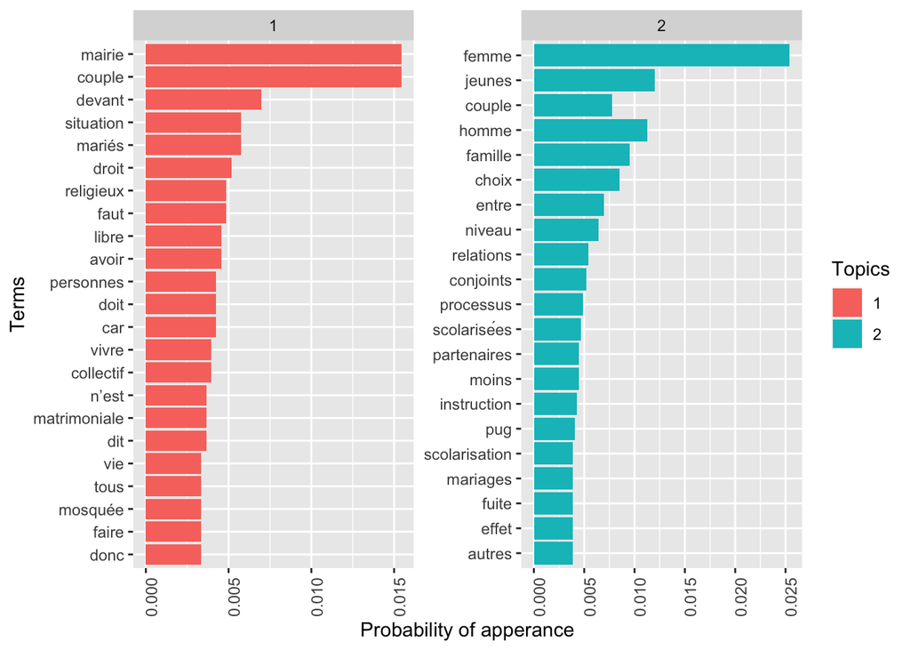

```r
# Creating an object for words' probabilities of appearance

word_prob_marriage <-
  lda_publications_topics_marriage %>%
  group_by(topic) %>%
  top_n(20, beta) %>%
  ungroup() %>%
  mutate(term2 = fct_reorder(term, beta))

# Ploting words' propabilities

ggplot(word_prob_marriage, aes(term2, beta, fill = as.factor(topic))) +
  geom_col() +
  facet_wrap(~ topic, scales = "free") +
  coord_flip() +
  theme(axis.text.x = element_text(angle = 90, hjust = 1)) +
labs(#title = paste("Topic Modeling for Marriage Registration in Burkina Faso"),
     x = "Terms",
     y = "Probability of apperance",
  fill = "Topics")
```

The first topic that has a collection of words appearing together with a high probability as **“mairie” (town hall)**, **“couple”, “mariés” (married)** is possibly on the celebration of civil marriage and therefore its registration. The marked presence of the word **“collectif”** is certainly an allusion to the celebration of collective civil marriages which happens to be a quite interesting phenomenon in Burkina Faso. Indeed, these are civil marriage ceremonies organized for several people at a time, by the same registrar, on the same day. This method appears here as a means of encouraging the registration of marriages. Thus, one question that comes to the mind is whether seeing one’s friend or relative perform a civil marriage can be a determining factor in the registration of a given individual’s marriage in Burkina Faso.

The interpretation of a topic model is quite subjective but already allows - with a certain mastery of the subject - to make certain predictions about the words that indicate a determinant of the registration of a vital event such as marriage.

# 4. Conclusion

The absence of a large number of publications on social norms does not allow conclusions to be drawn and some of the determinants to be predicted. For example, although I have obtained several texts on birth registration, very few deal with the socio-cultural barriers or norms that may hinder their registration. On the other hand, on marriage, I have reached more interesting conclusions, with fewer texts but oriented towards the social determinants that interest us. The results I have here can, in combination with the data that will be collected during field studies, confirm or refute some of our assumptions.

Ideally, I should be able to repeat this analysis with the transcripts from the interviews and focus groups and consolidate my interpretations based on the information gathered in the field.